# Política Judicial

Uma proposta de mensuração dos posicionamentos ideológicos dos Ministros do STF a partir das decisões proferidas em ações de controle concentrado de constitucionalidade ajuizadas por partidos políticos

Gustavo Henrique Catisane Diniz

2024-07-12

Para a mensuração do denominado “posicionamento ideológico” dos Ministros do Supremo Tribunal Federal foi criado um “proxy” consistente na diferença entre o número de decisões proferidas em processos de controle concentrado de constitucionalidade (ADC/ADI/ADPF) favoráveis a partidos políticos de esquerda ou de direita.

Tendo em vista que o número de processos ajuizados pelos partidos de direita é menor do que o número de processos ajuizados pelos partidos de esquerda (786 a 1341), foi atribuído o peso de 1,7 às decisões proferidas nos processos ajuizados pelos partidos de direita. A fim de evitar valores negativos, a cada um dos valores foi adicionado 50 unidades. Desse modo, valores acima de 50 revelam posicionamento ideológico à esquerda e valores abaixo de 50 revelam posicionamento ideológico à direita.

Os Ministros da Suprema Corte foram classificados ideologicamente com base na ideologia do Presidente que os indicou. Além dos processos ajuizados pelos partidos políticos, foram incluídos os ajuizados pelos Presidentes da República eleitos a partir de 1988. Foram consideradas as decisões proferidas após a promulgação da Constituição de 1988.

# Distribuição dos posicionamentos ideológicos dos Ministros do STF desde a Constituição de 1988

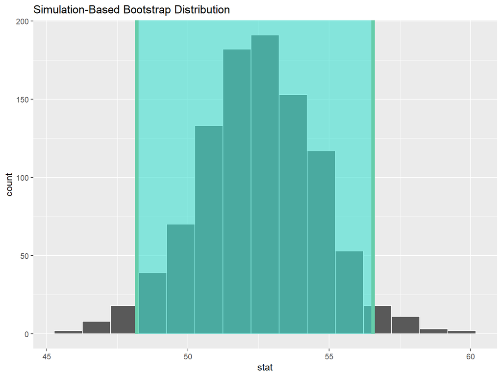

## Ações de controle concentrado de constitucionalidade ajuizadas por partidos políticos desde de 1988

| requerente_ideologia | acoes_ajuizadas | prop |
| --- | --- | --- |
| Direita | 786 | 36.95346 |
| Esquerda | 1341 | 63.04654 |

# Ideologia do Presidente responsável pela indicação do Ministro x Posicionamento ideológico do Ministro

| Ministro | Presidente_ideologia_indicacao | posicao_ideologia | posicao_ideologia_ajustada |
| --- | --- | --- | --- |
| MIN. ALEXANDRE DE MORAES | Direita | -0.8 | 49.2 |
| MIN. ANDRÉ MENDONÇA | Direita | 2.5 | 52.5 |
| MIN. AYRES BRITTO | Esquerda | 9.3 | 59.3 |
| MIN. CARLOS VELLOSO | Direita | 0.6 | 50.6 |
| MIN. CELSO DE MELLO | Direita | -1.6 | 48.4 |
| MIN. CEZAR PELUSO | Esquerda | -7.5 | 42.5 |
| MIN. CRISTIANO ZANIN | Esquerda | 23.9 | 73.9 |
| MIN. CÁRMEN LÚCIA | Esquerda | 28.6 | 78.6 |
| MIN. CÉLIO BORJA | Direita | 1.0 | 51.0 |
| MIN. DIAS TOFFOLI | Esquerda | 10.6 | 60.6 |
| MIN. EDSON FACHIN | Esquerda | 8.6 | 58.6 |
| MIN. ELLEN GRACIE | Direita | -2.2 | 47.8 |
| MIN. EROS GRAU | Esquerda | -3.8 | 46.2 |
| MIN. FLÁVIO DINO | Esquerda | 0.6 | 50.6 |
| MIN. GILMAR MENDES | Direita | -4.2 | 45.8 |
| MIN. ILMAR GALVÃO | Direita | -32.2 | 17.8 |
| MIN. JOAQUIM BARBOSA | Esquerda | -0.5 | 49.5 |
| MIN. LUIZ FUX | Esquerda | -15.8 | 34.2 |
| MIN. LUÍS ROBERTO BARROSO | Esquerda | 26.5 | 76.5 |
| MIN. MARCO AURÉLIO | Direita | 3.7 | 53.7 |
| MIN. MAURÍCIO CORRÊA | Direita | 1.5 | 51.5 |
| MIN. MENEZES DIREITO | Esquerda | 3.0 | 53.0 |
| MIN. MOREIRA ALVES | Direita | -3.4 | 46.6 |
| MIN. NELSON JOBIM | Direita | 2.0 | 52.0 |
| MIN. NUNES MARQUES | Direita | 1.2 | 51.2 |
| MIN. NÉRI DA SILVEIRA | Direita | -3.4 | 46.6 |
| MIN. RICARDO LEWANDOWSKI | Esquerda | 11.2 | 61.2 |
| MIN. ROSA WEBER | Esquerda | 19.0 | 69.0 |
| MIN. SEPÚLVEDA PERTENCE | Direita | -1.1 | 48.9 |
| MIN. SYDNEY SANCHES | Direita | 4.6 | 54.6 |
| MIN. TEORI ZAVASCKI | Esquerda | -3.4 | 46.6 |